# BART Fare Analysis

Timothy Sweetser https://twitter.com/hacktuarial

March 3, 2015

https://bart-fares.herokuapp.com/  
Have you ever wondered why you can’t buy a monthly pass on BART? As a daily BART commuter, I spend almost $150 a month on BART fares. According to their website, “BART fares are set with a mileage-based formula, therefore time-based passes (e.g., weekly or monthly) are not available.” Using BART’s fare table, and Google Maps driving directions, I determined that the formula is:  
Fare = $1.55 + $0.108 x Miles Traveled + Following Surcharges:  
$5 for traveling to/from San Francisco International Airport  
$1 for using the Transbay Tube between Oakland and San Francisco  
$1 for traveling to/from San Mateo county

How did I figure this out?

For distance, I used Python to calculate Euclidean distance (“as the crow flies”) between stations using [Vincenty distance](http://en.wikipedia.org/wiki/Vincenty%27s_formulae) in the $geopy$ package. Each station’s latitude and longitude is available from [BART’s website](http://www.bart.gov/schedules/developers/gtfs). The fares are also available there. I merge these together, calculate some dummy variables, and use linear regression to get the above formula.  
* Read in data, and load required packages.

```r
library(MASS)
library(dplyr, quietly=T)
```

```r
library(magrittr)
library(ggplot2)
setwd('/Users/timothysweetser/Box Sync/BART Project')
distance <- read.csv("data/bart/Euclidean miles.csv", colClasses=c('character', 'numeric', 'numeric', 'character'))
fare_attributes <- read.csv("google_transit_2/fare_attributes.txt", colClasses=c('character', 'numeric', 'character', 'character', 'character', 'character', 'character'))
fare_rules <- read.csv("google_transit_2/fare_rules.txt", colClasses=rep('character', 5))
stops <- read.csv("google_transit_2/stops.txt", colClasses=c('character', 'character', 'character', 'numeric', 'numeric', 'character', 'character'))
min.fare <- min(fare_attributes$price)
```

For the transbay dummy variable, we will need to know which side of the San Francisco Bay each station is on. I know that Richmond is the western-most station in the East Bay, and Embarcadero is the eastern-most station in the West Bay. Therefore, the midpoint of their longitudes will be the dividing line.

```r
bay.line <- mean(stops[stops$stop_id %in% c("RICH", "EMBR"), 'stop_lon'])
stops %<>% mutate(., bayside = ifelse(stop_lon < bay.line, "W", "E"))
```

Now let’s work on fares; I will merge attributes and rules together, then add a transbay indicator.

```r
fares <- inner_join(fare_attributes, fare_rules, by = "fare_id")
fares <- stops %>% dplyr::select(., stop_id, bayside) %>% rename(., bayside_orig = bayside) %>% inner_join(fares, ., by=c("origin_id"="stop_id"))
fares <- stops %>% dplyr::select(., stop_id, bayside) %>% rename(., bayside_dest = bayside) %>% inner_join(fares, ., by=c("destination_id"="stop_id"))

fares %<>% mutate(., TransBay = as.factor(bayside_orig != bayside_dest))

data <- merge(distance, fares %>% dplyr::select(., price, TransBay, origin_id, destination_id), by.x=c('Orig', 'Dest'), by.y=c('origin_id', 'destination_id'))
# export for further visualization
write.csv(data, 'data/BART/crow flies distance.csv', row.names=F)
source("export_to_json.R")
```

Remove trips starting and beginning at the same station, and only keep the variables we need. We can also remove symmetric trips, since for each pair of stations, the distance and fare are the same whichever direction you travel in.

```r
data %<>% filter(., Orig != Dest) %>% dplyr::select(Dest, Orig, EuclidMiles, price, TransBay)
keepers <- NULL
for (i in 1: nrow(data)) {
  sister.row <- intersect(which(data$Dest == data$Orig[i]),
                      which(data$Orig == data$Dest[i]))
  keepers <- c(keepers,min(i,sister.row,na.rm=T))
}
data <- data[unique(keepers), ]
```

Create dummy variables for San Francisco Airport and San Mateo County.

```r
SanMateo <- c('DALY', 'COLM', 'SSAN', 'SBRN', 'MLBR')
data %<>% mutate(., Airport = as.factor(Orig == 'SFIA' | Dest == 'SFIA'),
                    SanMateo = as.factor(Dest %in% SanMateo | Orig %in% SanMateo))
```

Plot the data.

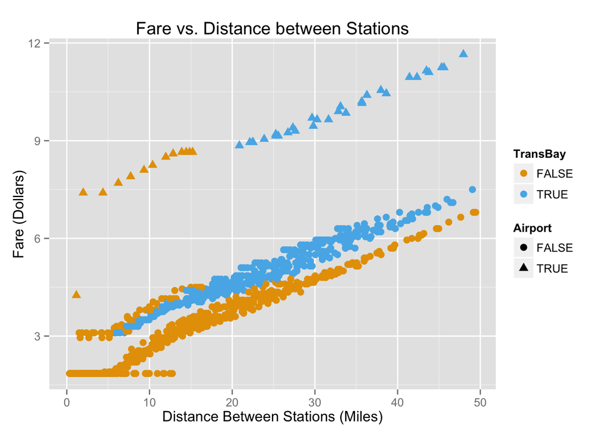

```r
# color palette from http://www.cookbook-r.com/Graphs/Colors_(ggplot2)/
cbPalette <- c("#999999", "#E69F00", "#56B4E9", "#009E73", "#F0E442", "#0072B2", "#D55E00", "#CC79A7")
p <- ggplot(data, aes(x=EuclidMiles, y=price, color=TransBay)) + geom_point(aes(shape=Airport), size=2.75) +
  scale_color_manual(values=cbPalette[2:3]) +
  xlab("Distance Between Stations (Miles)") +
  ylab("Fare (Dollars)") +
  ggtitle("Fare vs. Distance between Stations")
print(p)
```

Highlights:  
1. Fare does seem to follow a linear pattern with Distance Traveled  
2. Trips to SFO really are more expensive, and they seem to be parallel to non-SFO trips.  
3. Trips across the San Francisco Bay (in blue) are more expensive  
4. Trips to/from San Mateo county are more expensive - see the low-mileage, orange triangles in the upper-left. 5. There are a lot of trips with the minimum fare, $1.85. These form a horizontal line.  
Now, let’s fit a linear regression model to estimate the exact cost of each of these.

```r
mat <- lm(price ~ EuclidMiles + Airport*TransBay + SanMateo*TransBay, data)
summary(mat)
```

```
##
## Call:
## lm(formula = price ~ EuclidMiles + Airport * TransBay + SanMateo *
##     TransBay, data = data)
##
## Residuals:
##     Min      1Q  Median      3Q     Max
## -3.3803 -0.0979 -0.0052  0.1134  0.7456
##
## Coefficients:
##                             Estimate Std. Error t value Pr(>|t|)
## (Intercept)                1.5502156  0.0163686   94.71   <2e-16 ***
## EuclidMiles                0.1084672  0.0007735  140.23   <2e-16 ***
## AirportTRUE                4.9100204  0.0640315   76.68   <2e-16 ***
## TransBayTRUE               0.9748618  0.0181283   53.78   <2e-16 ***
## SanMateoTRUE               1.0446090  0.0330760   31.58   <2e-16 ***
## AirportTRUE:TransBayTRUE  -1.0460322  0.0784758  -13.33   <2e-16 ***
## TransBayTRUE:SanMateoTRUE -1.3759021  0.0422110  -32.60   <2e-16 ***
## ---
## Signif. codes:  0 '***' 0.001 '**' 0.01 '*' 0.05 '.' 0.1 ' ' 1
##
## Residual standard error: 0.2254 on 939 degrees of freedom
## Multiple R-squared:  0.9833, Adjusted R-squared:  0.9832
## F-statistic:  9199 on 6 and 939 DF,  p-value: < 2.2e-16
```

The surcharges do not simply stack up if your trip covers more than one of them. For example, if you cross the bay and go to/from San Francisco Airport, you pay a surcharge of $4.85 instead of $5.85. Likewise if you cross the bay and go to/from San Mateo county, your surcharge is only $0.65, less than if you did only one of those!

Let’s try another model, where the minimum price is $1.85, and the first $free.miles$ miles are free. We’ll pick $free.miles$ to maximize $R^2$, the amount of variation explained by the model.

```r
best <- 0
best.model <- lm(price ~ 0 + EuclidMiles + Airport*TransBay + SanMateo*TransBay, data, offset=rep(min.fare, nrow(data)))
for(free.miles in 1:30) {
  data$Miles2 <- pmax(0, data$EuclidMiles - free.miles)
  mat.no.int <- lm(price ~ 0 + Miles2 + Airport*TransBay + SanMateo*TransBay, data, offset=rep(min.fare, nrow(data)))
  if (summary(mat.no.int)$r.squared > summary(best.model)$r.squared) {
    best.model <- mat.no.int
    best <- free.miles
  }
}
```

The best model, with an exogenously provided intercept, shows that the first mile is free. This model’s $R^2$ is 0.998, a bit better than the model which chooses its own intercept $R^2 =$ 0.983.

One problem with both of these models is that there are some high leverage points. Ideally, each point should have the same influence on the model, but you can see there are several that really stand out.

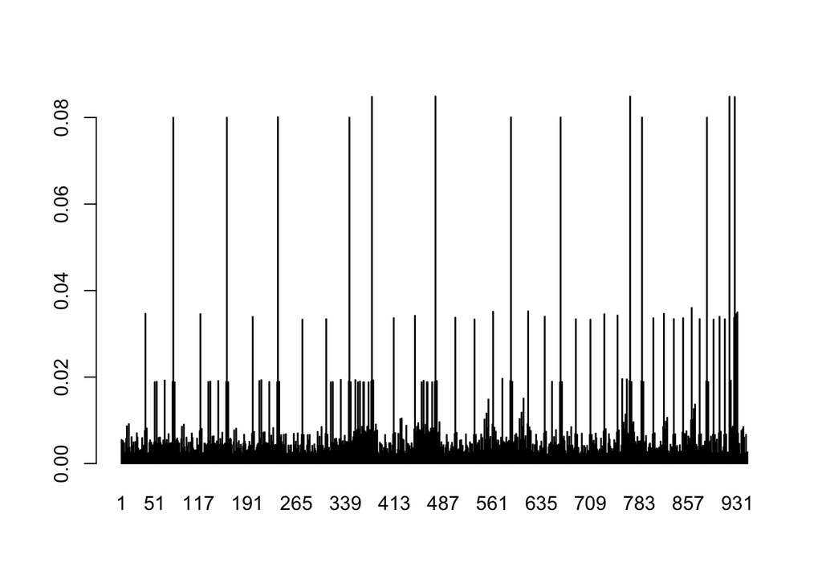

```r
barplot(hatvalues(mat))
```

```r
data[order(hatvalues(mat), decreasing = T)[1:10], 1:4]
```

```
##     Dest Orig EuclidMiles price
## 769 SFIA MLBR    1.157030  4.25
## 475 SFIA DALY    7.719167  7.90
## 919 SFIA SBRN    1.983308  7.40
## 379 SFIA COLM    6.229396  7.70
## 927 SSAN SFIA    4.368827  7.40
## 237 SFIA BALB    9.333349  8.10
## 589 SFIA EMBR   15.216904  8.65
## 664 SFIA GLEN   10.383031  8.25
## 787 SFIA MONT   14.854950  8.65
## 885 SFIA POWL   14.436016  8.65
```

All of the 10 most troublesome trips involve the San Francisco International Airport, denoted here as $SFIA$. One way to deal with this is robust regression, which calculates the coefficients, reduces the weight on highly influential points, recalculates the coefficients, etc. until it converges, i.e. the coefficients stop changing.

```r
rrr <- rlm(price ~ EuclidMiles + Airport*TransBay + SanMateo*TransBay, data)
round(data.frame("Simple_Model"=mat$coefficients, "First_Mile_Free"=c(min.fare, best.model$coefficients[c(1, 3:7)]), "Robust"=rrr$coefficients), 3)
```

```
##                           Simple_Model First_Mile_Free Robust
## (Intercept)                      1.550           1.850  1.570
## EuclidMiles                      0.108           0.109  0.107
## AirportTRUE                      4.910           4.718  5.429
## TransBayTRUE                     0.975           0.975  0.977
## SanMateoTRUE                     1.045           1.046  1.122
## AirportTRUE:TransBayTRUE        -1.046          -1.048 -1.547
## TransBayTRUE:SanMateoTRUE       -1.376          -1.378 -1.445
```

As you can see, the three models largely agree, especially on the per-mile charge of almost 11 cents. Here is the graph again, with the *robust* model overlaid.

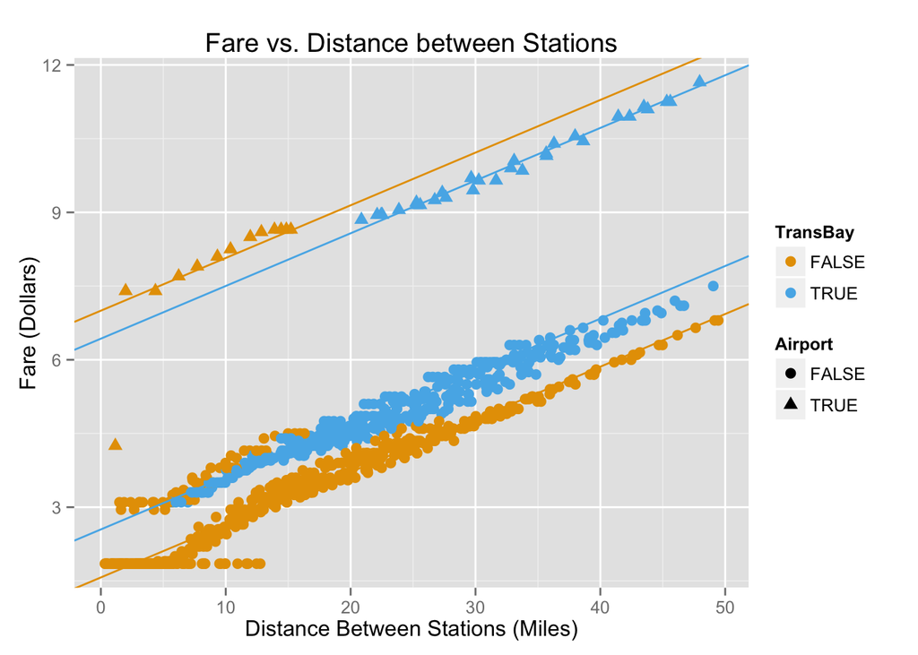

```r
plot.data <- data.frame('EuclidMiles'=rep(0, 4),
                        'Airport'= c(T, T, F, F) %>% as.factor,
                        'TransBay'=c(T, F, T, F) %>% as.factor,
                        'SanMateo'=rep(F, 4) %>% as.factor)
plot.data$int <- predict(rrr, plot.data)
plot.data$slope <- coef(rrr)[2]
p + geom_abline(aes(intercept=int, slope=slope, color=TransBay), data=plot.data)
```

Besides San Francisco and [DC](http://planitmetro.com/2012/11/15/how-are-metrorail-fares-calculated/), and single-line PATCO, every other [major rapid transit system in the US](http://en.wikipedia.org/wiki/List_of_United_States_rapid_transit_systems_by_ridership) charges a flat fee, no matter how far you ride. This is because most other systems are complemented by a regional commuter rail system, covering greater distances with longer headways. BART and DC Metro, however, function as both commuter rail systems in the suburbs, but also as rapid transit systems in the urban centers. Because of this dual purpose, 2-systems-in-one nature, both systems use mileage-based fares.